# Numeracy Assignment Notebook

Hari Subhash Data Scientist @NRGI

2018-09-23

[output not shown]

**Description**: This notebook is a quick summary of the relation between [wealth](http://www.worldbank.org/en/news/infographic/2018/01/30/the-changing-wealth-of-nations) and gdp per capita. Both these data sources were downloaded from the [World Bank Databank](http://databank.worldbank.org/data/home.aspx). The downloaded data were copied to `Numeracy Data` spreadsheet on Google Drive so that it is easy to share.

```r
rm(list = ls())
library(tidyverse); library(googlesheets); library(ggthemes); library(ggridges)

##load all the different data
gdpData <- gs_title("Numeracy Data") %>%
    gs_read(ws = "GDP Data") %>%
    select(country = `Country Name`, year = Time, gdp = Value)

wealthData <- gs_title("Numeracy Data") %>%
    gs_read(ws = "Wealth Data") %>%
    select(country = `Country Name`, wealthIndicator = `Series Name`, year = Time, value = Value)

countryClassification <- gs_title("Numeracy Data") %>%
    gs_read(ws = "WB Classification") %>%
    select(country = Economy, region = Region, income = `Income group`)
```

## Prompt 1: Trends in GDP per capita

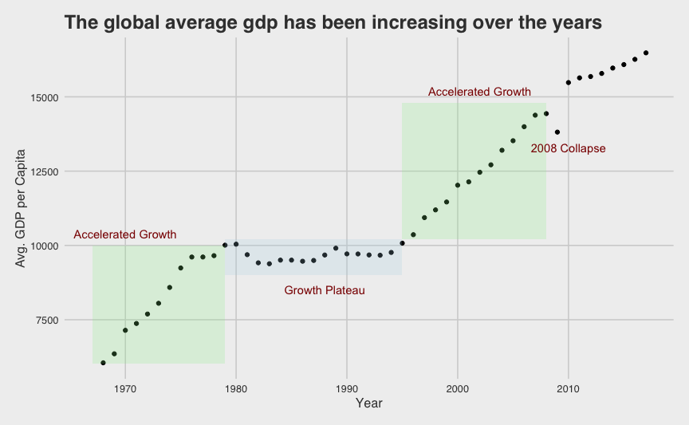

Overall, the average GDP per capita in the world seems to have been increasing i.e. the average income of humans have increased dramatically. However, there is an important question to consider i.e. is this true for countries from different regions or income levels?

The next chart shows that it isn’t as straightforward. While the overall gdp has increased for all regions during the period of the data, most regions have gone through remarkable periods of fluctuating growth. While some regions like North and Latin America have seem to have grown consistently other regions seem to have experienced more fluctuating growth trends.

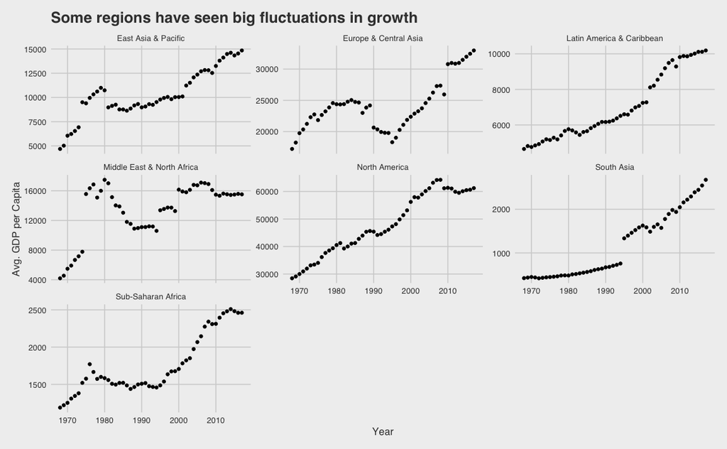

There also seem to be some strange kinks in the data.[^1] This could either be a calculation mistake or an artefact of the data. For instance, look at Middle East around 1975 and South Asia around 1995. The average GDP per capita for these regions seem to experience a remarkable jump around these years. Why might this be?

My hunch is that this is because of missing data i.e. say a high GDP per capita country has certain years of data missing, in the years that the country is present the average gdp will be high while for years that it is missing it will be lower, thereby introducing a ‘kink’ in the chart.

We can see if this is true by plotting the same chart as below but without the averages. Lets do that for the middle east region. The chart below shows that my initial hunch was true i.e. there are several countries like Kuwait, Israel, Lebanon etc that have data only from a certain point onwards. However, this does not fully explain all the fluctuations in GDP per capita in the Middle East.

Another thing to note here is that the chart below (unlike the previous two charts), shows the actual gdp per capita numbers for each of these countries instead of the averaged out values for each region/world. This points to one of the issues with taking averages. Whenever we take a summary statistic (for instance, mean/median/mode) we lose the nuance in the data by ‘smoothing’ the fluctuations in the underlying data.. In this case, because we looked at the overall regional average, we lose information about country specific fluctuations in the data, which could indicate underlying patterns.

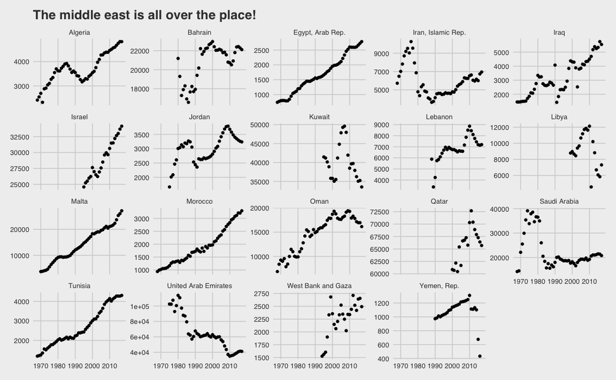

**Question 1**: It is interesting that the GDP of the middle east flutuates, any guesses for a few reasons that might explain this and how we might further explore that??

**Hint**: Its something that is relevant to our work!

To wind this section up, lets look at the movement of gdp for different income categories. While most income groups have seen an increase in GDP per capita, the average for low income countries have not seen an increase in the time period with data.

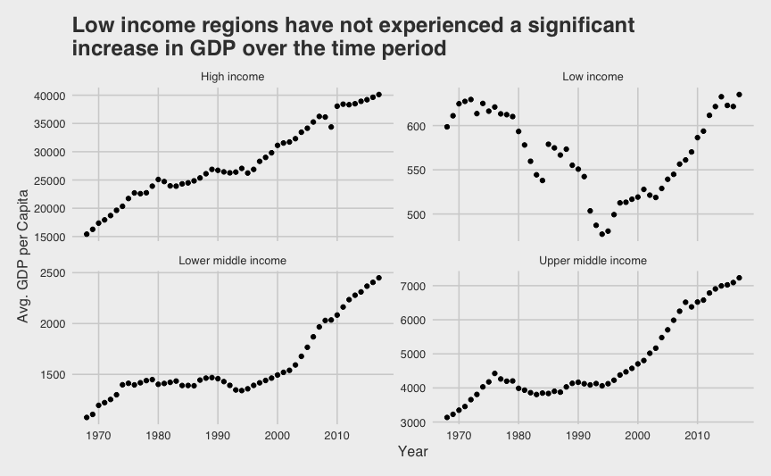

**Question 2**: Why might this be the case? How would you go about answering this?

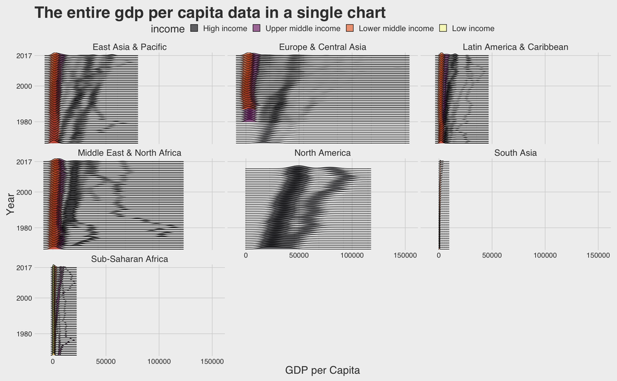

## Prompt 2: The relationship between wealth and gdp

Lets explore this during the next call.

[^1]: Kinks are sharp departures from a trend. For instance, observe South Asia, there seems to be a sudden jump in the average gdp per capita around 1195. Such sudden shifts indicate some underlying data feature that could be driving these shifts.